# Chapter 6. Product Limit stimator Peter smith

### Required libraries

```r
library(survival)
```

```r
knitr::include_graphics("6_2.PNG")
```

[output not shown]

```r
NA
```

### Required data

```r
### Patients whowere given 6-mercaptopurine
### The time for 6-MP and the placebo time were given in weeks

MP <- c(6,6,6,6,7,9,10,10,11,13,16,17,19,20,22,23,25,32,32,34,35)
cens1 <- c(1,1,1,0,1,0,1,0,0,1,1,0,0,0,1,1,0,0,0,0,0)

### Patients who were given Placebo

placebo <- c(1,1,2,2,3,4,4,5,5,8,8,8,8,11,11,12,12,15,17,22,23)
cens2 <- rep(1,21)
```

### Joining the Data

```r
### Joining the MP and placebo data in the same vector

Total <- c(MP,placebo)

### Converting the given times to months by dividing the number of weeks/4.345

Total <- Total/4.345

### Joining the MP and placebo censored data in the same vector

cens <- c(cens1, cens2)

### Creating data groups MP = 1, Placebo = 0

groups <- c(rep(1,21),rep(0,21))
```

### PL-Estimator

```r
### Calculating the PL estimator using the survival library

km.model <- survfit(Surv(Total,cens)~ groups)
```

### Comparation Chart

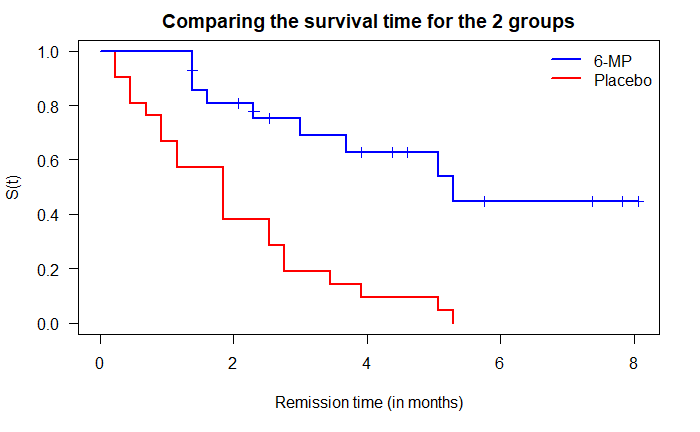

```r
plot(km.model, conf.int=F,col=c("red", "blue"), xlab = "Remission time (in months)", ylab = "S(t)", main="Comparing the survival time for the 2 groups", mark.time = TRUE, lwd = 2, las=1)
legend("topright", legend=c("6-MP","Placebo"), lty = 1, lwd = 2, col=c("blue", "red"), bty="n")
```

```r
knitr::include_graphics("6_2_a.PNG")
```

[output not shown]

From the analysis of the graphs, it can be seen that the time for the treatment group administered the 6-MP steroid to enter remission is longer than that of the patients administered the placebo. We can also see that the survival function for the treatment group is above that of the placebo group, clearly indicating that the efficacy of the 6-MP steroid, of course this is not the case at all times and the survival function for both groups is maintained at 100%, until the first week where both graphs are far apart, corroborating the effectiveness of the treatment because the risk of entering remission is lower.

```r
knitr::include_graphics("6_2_b.PNG")
```

[output not shown]

Using the graphs for both groups we can estimate that the probability of survival, i.e. not entering remission after 3 months, for the treatment group is about 70%, while for the placebo group it is about 20%.

```r
knitr::include_graphics("6_2_c.PNG")
```

[output not shown]

```r
### summary function on the KM model

summary(km.model)
```

```
Call: survfit(formula = Surv(Total, cens) ~ groups)

                groups=0
  time n.risk n.event survival std.err lower 95% CI upper 95% CI
 0.230     21       2   0.9048  0.0641      0.78754        1.000
 0.460     19       2   0.8095  0.0857      0.65785        0.996
 0.690     17       1   0.7619  0.0929      0.59988        0.968
 0.921     16       2   0.6667  0.1029      0.49268        0.902
 1.151     14       2   0.5714  0.1080      0.39455        0.828
 1.841     12       4   0.3810  0.1060      0.22085        0.657
 2.532      8       2   0.2857  0.0986      0.14529        0.562
 2.762      6       2   0.1905  0.0857      0.07887        0.460
 3.452      4       1   0.1429  0.0764      0.05011        0.407
 3.913      3       1   0.0952  0.0641      0.02549        0.356
 5.063      2       1   0.0476  0.0465      0.00703        0.322
 5.293      1       1   0.0000     NaN           NA           NA

                groups=1
 time n.risk n.event survival std.err lower 95% CI upper 95% CI
 1.38     21       3    0.857  0.0764        0.720        1.000
 1.61     17       1    0.807  0.0869        0.653        0.996
 2.30     15       1    0.753  0.0963        0.586        0.968
 2.99     12       1    0.690  0.1068        0.510        0.935
 3.68     11       1    0.627  0.1141        0.439        0.896
 5.06      7       1    0.538  0.1282        0.337        0.858
 5.29      6       1    0.448  0.1346        0.249        0.807
```

Using the summary function on the kaplan-maier model, to calculate the estimated value of the survival function beyond 3 months, we have that for the group to which the treatment was administered it was 69%, while for the placebo group it was 19.05%.

```r
knitr::include_graphics("6_3.PNG")
```

[output not shown]

To fill in the values of the PL- estimator for 6-MP group, we will use definition 6.3 to manually calculate the values as shown below.

```r
### Turning data into a DF

mpData <- as.data.frame(cbind(MP, cens1))
```

Manual calculation

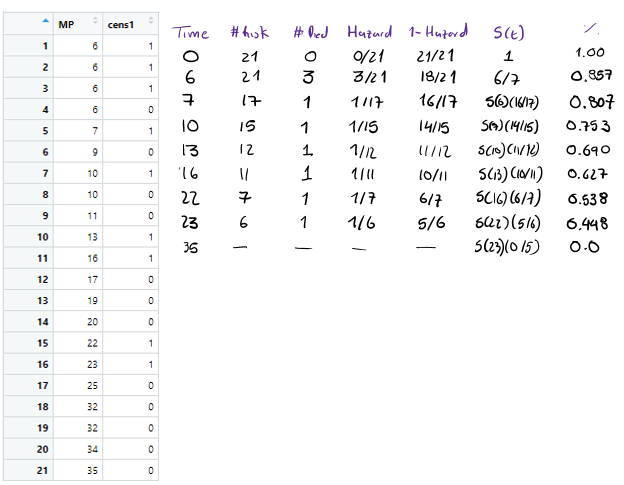

```r
knitr::include_graphics("6_3R.png")
```

```r
NA
```

To verify the calculations performed we will calculate the KM estimator on the training group data only.

```r
km.modelMP <- survfit(Surv(MP,cens1)~ 1)
summary(km.modelMP)
```

```
Call: survfit(formula = Surv(MP, cens1) ~ 1)

 time n.risk n.event survival std.err lower 95% CI upper 95% CI
    6     21       3    0.857  0.0764        0.720        1.000
    7     17       1    0.807  0.0869        0.653        0.996
   10     15       1    0.753  0.0963        0.586        0.968
   13     12       1    0.690  0.1068        0.510        0.935
   16     11       1    0.627  0.1141        0.439        0.896
   22      7       1    0.538  0.1282        0.337        0.858
   23      6       1    0.448  0.1346        0.249        0.807
```

As we can see the summary function shows that the manually calculated data match the data generated by the software.

```r
knitr::include_graphics("6_6.PNG")
```

[output not shown]

```r
NA
```

### Required data

```r
## Stanford Heart Transplat Data

## Reading data

heart <- read.csv("heart_data.csv", header=T,sep=";")
### Shows the first 5 rows
head(heart)
```

|  | Days | Cens | Age | T5 |
| --- | --- | --- | --- | --- |
| 1 | 15 | 1 | 54.3 | 1.11 |
| 2 | 3 | 1 | 40.4 | 1.66 |
| 3 | 624 | 1 | 51.0 | 1.32 |
| 4 | 46 | 1 | 42.5 | 0.61 |
| 5 | 127 | 1 | 48.0 | 0.36 |
| 6 | 64 | 1 | 54.6 | 1.89 |

```r
### Data sorting based on the amount of days

i <- order(heart$Days)
heart <- heart[i,]

### Shows the first 5 rows from the sorted data

head(heart)
```

|  | Days | Cens | Age | T5 |
| --- | --- | --- | --- | --- |
| 16 | 1 | 1 | 54.2 | 0.47 |
| 68 | 1 | 0 | 35.2 | 0.67 |
| 69 | 1 | 1 | 41.5 | 0.87 |
| 2 | 3 | 1 | 40.4 | 1.66 |
| 10 | 10 | 1 | 55.3 | 2.76 |
| 48 | 12 | 1 | 29.2 | 0.61 |

### PL- Estimator

```r
km.modelH <- survfit(Surv(heart$Days,heart$Cens)~1)

st <-km.modelH$surv
tekm <- km.modelH$time
inv_Phi <- qnorm(st)
```

### Graficando probabilidad

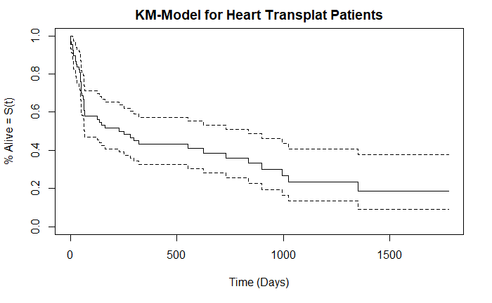

```r
plot(km.modelH, conf.int=T, xlab = "Time (Days)", ylab="% Alive = S(t)", main="KM-Model for Heart Transplat Patients")
```

```r
summary(km.modelH)
```

```
Call: survfit(formula = Surv(heart$Days, heart$Cens) ~ 1)

 time n.risk n.event survival std.err lower 95% CI upper 95% CI
    1     69       2    0.971  0.0202       0.9322        1.000
    3     66       1    0.956  0.0247       0.9091        1.000
   10     65       1    0.942  0.0283       0.8876        0.999
   12     64       1    0.927  0.0315       0.8672        0.991
   14     62       1    0.912  0.0343       0.8470        0.982
   15     61       1    0.897  0.0369       0.8275        0.972
   23     60       1    0.882  0.0392       0.8085        0.962
   25     59       1    0.867  0.0413       0.7898        0.952
   26     58       1    0.852  0.0432       0.7715        0.941
   29     57       1    0.837  0.0449       0.7536        0.930
   39     55       1    0.822  0.0466       0.7355        0.919
   44     54       1    0.807  0.0482       0.7176        0.907
```

[output cut: 29 more lines]

```r
knitr::include_graphics("6_6_1.PNG")
```

[output not shown]

```r
NA
```

Using the summary function, it is estimated that the probability that the patient will live for more than one year after transplantation is approximately 43%, with a estimate standar error of 0.0620

```r
knitr::include_graphics("6_6_2.PNG")
```

[output not shown]

```r
NA
```

The probability of survival after 6 to the next 6 months after heart transplantation decreases based on the model calculated in this way and the probability of survival between months 7 to 12 is given respectively by the following:

```r
### Calculating the survival probability between the months 7 to 12

result.summ <- summary(km.modelH, time=c(seq(7,12)*30.417))
month <- (result.summ$time)/30.417
St <- result.summ$surv
data.frame(month, St)
```

| month | St |
| --- | --- |
| 7 | 0.5158837 |
| 8 | 0.4997623 |
| 9 | 0.4831036 |
| 10 | 0.4497861 |
| 11 | 0.4324866 |
| 12 | 0.4324866 |